# Einblick in die Arbeit mit *zufall*

von Holger Böttcher - hbomat@posteo.de  
Diese Arbeit steht unter der freien Lizenz [CC BY-SA 4.0](https://creativecommons.org/licenses/by-sa/4.0/deed.de)

### Abitur Bayern 2019

### Stochastik Teil B, Aufgabengruppe 2

Quelle: [serlo.org](https://de.serlo.org/mathe/deutschland/bayern/gymnasium/abiturpr%C3%BCfungen-l%C3%B6sung/mathematik-abitur-bayern-2019/stochastik,-teil-b,-aufgabengruppe-2)

**1.** Jeder sechste Besucher eines Volksfestes trägt ein Lebkuchenherz um den Hals.  
Während der Dauer des Volksfests wird 25-mal ein Besucher zufällig ausgewählt.  
Die Zufallsgröße $X$ beschreibt die Anzahl der ausgewählten Besucher, die ein  
Lebkuchenherz tragen.

$\quad$**a)** Bestimmen Sie die Wahrscheinlichkeit dafür, dass unter den ausgewählten  
$\quad\:\:\:\:$Besuchern höchstens ein Besucher ein Lebkuchenherz trägt.

$\quad$**b)** Beschreiben Sie im Sachzusammenhang ein Ereignis, dessen  
$\quad\:\:\:\:$Wahrscheinlichkeit mit dem Term $\sum_{i=5}^8 B(25;16;\,i)$ berechnet werden kann.

$\quad$**c)** Bestimmen Sie die Wahrscheinlichkeit dafür, dass der Wert der Zufallsgröße
$\quad\:\:\:\:$$X$ höchstens um eine Standardabweichung vom Erwartungswert der
$\quad\:\:\:\:$Zufallsgröße abweicht.

**2.** Bei einer Losbude wird damit geworben, dass jedes Los gewinnt. Die Lose und die  
zugehörigen Sachpreise können drei Kategorien zugeordnet werden, die mit "Donau",  
"Main" und "Lech" bezeichnet werden. Im Lostopf befinden sich viermal so viele Lose  
der Kategorie "Main" wie Lose der Kategorie "Donau". Ein Los kostet 1 Euro. Die  
Inhaberin der Losbude bezahlt im Einkauf für einen Sachpreis in der Kategorie  
"Donau" 8 Euro, in der Kategorie "Main" 2 Euro und in der Kategorie "Lech" 20 Cent.  
Ermitteln Sie, wie groß der Anteil der Lose Kategorie "Donau" sein muss, wenn die  
Inhaberin im Mittel einen Gewinn von 35 Cent pro Los erzielen will.

**3.** Die Inhaberin der Losbude beschäftigt einen Angestellten, der Besucher des  
Volksfests anspricht, um diese zum Kauf von Losen zu animieren. Sie ist mit der  
Erfolgsquote des Angestellten unzufrieden.

$\quad$**a)** Die Inhaberin möchte dem Angestellten das Gehalt kürzen, wenn weniger als  
$\quad\:\:\:\:$15% der angesprochenen Besucher Lose kaufen. Die Entscheidung über die  
$\quad\:\:\:\:$Gehaltskürzung soll mithilfe eines Signifikanztests auf der Grundlage von 100  
$\quad\:\:\:\:$angesprochenen Besuchern getroffen werden. Dabei soll möglichst vermieden  
$\quad\:\:\:\:$werden, dem Angestellten das Gehalt zu Unrecht zu kürzen. Geben Sie die  
$\quad\:\:\:\:$entsprechende Nullhypothese an und ermitteln Sie die zugehörige  
$\quad\:\:\:\:$Entscheidungsregel auf dem Signifikanzniveau von 10%.

$\quad$**b)** Der Angestellte konnte bei der Durchführung des Tests zehn von 100  
$\quad\:\:\:\:$erwachsenen Besuchern dazu animieren, Lose zu kaufen. Er behauptet, dass er  
$\quad\:\:\:\:$zumindest bei Personen mit Kind eine Erfolgsquote größer als 10% habe. Unter  
$\quad\:\:\:\:$den 100 angesprochenen Besuchern befanden sich 40 Personen mit Kind. Von  
$\quad\:\:\:\:$den Personen ohne Kind zogen 54 kein Los. Überprüfen Sie, ob das Ergebnis  
$\quad\:\:\:\:$der Stichprobe die Behauptung des Angestellten stützt.

```python
%run zufall/start
```

### Zu 1.

Es liegt eine Bernoullikette vor, $X$ ist binomialverteilt mit $n=25$ und der  
Trefferwahrscheinlichkeit $\frac{1}{6}$

```python
bk = BK(25, 1/6)   # BK - BernoulliKette
```

```
Erzeugung eines BernoulliKette-BinomialVerteilung-Objektes
```

### a)

```python
P = bk.P    # temporäre Umbenennng der P-Methode von bk
```

```python
P(X <= 1)
```

$$\frac{298023223876953125}{4738381338321616896}$$

```python
 P(X <= 1, p=ja)   # in Prozent
```

$$6.29$$

### b)

Mit der Formel wird die Wahrscheinlichkeit dafür berechnet, dass $X$ Werte aus dem  
Intervall $[5,\;8]$ annimmt

("mindestens 5 und höchstens 8 tragen ein Lebkuchenherz")

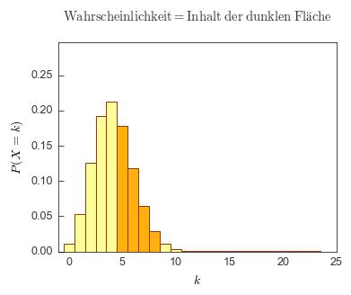

```python
P('5 <= X <= 8', g=ja)
```

```python
P('5 <= X <= 8'), P('5 <= X <= 8').n()
```

$$\left ( \frac{3701229095458984375}{9476762676643233792}, \quad 0.390558381775368\right )$$

### c)

```python
e = bk.erw; si = bk.sigma
e, e.n(3)
```

$$\left ( \frac{25}{6}, \quad 4.17\right )$$

```python
si, si.n(3)
```

$$\left ( \frac{5 \sqrt{5}}{6}, \quad 1.86\right )$$

```python
P('-1.86 + 25/6 < X < 1.86 + 25/6', p=ja)
```

$$70.21$$

### Zu 2.

Für die Zufallsgröße Gewinn = "Reingewinn für ein Los" (in Euro) ergibt sich mit  
$p$ = Wahrscheinlichkeit dafür, dass ein Los "Donau" gezogen wird, die  
Wahrscheinlichkeitsverteilung

$\{ \text{Donau}: p, \text{Main}: 4p, \text{Lech}: 1\,-\,5p \}$

Reingewinn ist der Lospreis minus dem Preis für den Sachpreis (für jedes Los);  
das ergibt die Tabelle

$\{ \text{Donau}: -7, \text{Main}: -1, \text{Lech}: 0.8 \}$

Nach der Formel für den Erwartungswert muss die Summe der Produkte der  
entsprechenden Elemente der beiden Tabellen gebildet und dem vorgegebenen  
Wert von $0.35$ gleichgesetzt werden

Zur Lösung ist die entstehende Gleichung so umzuformen, dass ihre rechte Seite  
gleich Null ist; die linke Seite wird dann benutzt

```python
gl = -7*p -4*p +0.8*(1-5*p) - 0.35
gl
```

$$- 15.0 p + 0.45$$

```python
löse(gl)
```

$$\left \{ p : \frac{3}{100}\right \}$$

Als Lösung ergibt sich $p = 3\%$

### Zu 3.

### a)

Die Nullhypothese ergibt sich zu $H_0: p \ge 0.15$, der Test ist

```python
test = STP(0.15, 0.1, 'links', 100, 'B')
```

```python
test.regel
```

$$\mathrm{Ermittlung\; der\; Entscheidungsregel\; für\; den\; Signifikanztest}$$

$$\mathrm{Gegeben}$$

$$\qquad \mathrm{H_0}:\;p \ge0.15$$

$$\qquad\alpha=0.1,\;n=100,\;\mathrm{linksseitiger\;Test}$$

$$\qquad\text{Prüfgröße} \;\; X=\text{"Anzahl Treffer"}$$

$$\qquad\text{Verteilung von }X\;\;BinomialVerteilung(100,3/20)$$

$$\mathrm{Kritische\;Zahl\;\;}10$$

$$\mathrm{Ablehnungsbereich\;für\;}H_0\;\; X \le10$$

$$\mathrm{Entscheidungsregel}$$

$$\mathrm{Liegt\;der\;Wert\;der\;Prüfgröße\;im\;Ablehnungsbereich,\;wird\;} H_0\text{ mit einer Irrtums-}$$

$$\mathrm{wahrscheinlichkeit\;von\;höchstens\;}0.1\mathrm{\;abgelehnt,\;sonst\;wird\;}H_0\text{ beibehalten}$$

### b)

Die Erfolgsquote des Angestellten bei den 100 angesprochenen erwachsenen  
Besuchern ist 10% (er hat an 100 Besucher 10 Lose verkauft).

40 Personen von allen 100 davon haben ein Kind. Damit haben 60 kein Kind.  
Von diesen zogen 54 kein Los. Also 6 ein Los.

Die verbleibenden 4 Lose wurden also von den 40 Persoen mit Kind gekauft.  
Damit ist der Anteil der von Besuchern mit Kind gekauften Lose ebenfalls (nur) 10%.

Ergebnis:

Das Ergebnis der Stichprobe stützt die Behauptung des Angestellten nicht.